# Case study of the “Risk Assessment GmbH”

*Autor: Dennis Triepke*  
*Date: 26.06.2017*

You are the new extraordinary Data Scientist of the “Risk Assessment GmbH” and you really want to become a part of this company. The “Risk Assessment GmbH” is a leading company for modelling speciﬁc risks of customers. They develop models based on diﬀerent statistical and machine learning algorithms. As part of your job you have to solve a speciﬁc case study for this company and provide a solution which could be implemented. Remark: There are several ways to solve this task, but please ﬁnd a reasonable way!

# Initialisation

```r
# Clear environment
rm(list = ls(all = TRUE))
# Packages
library(dplyr)
library(lattice)
library(ggplot2)
library(plotly)
# Helping functions
count_na <- function(x, rel = TRUE){

  if(rel){
    return(is.na(x) %>% sum() / x %>% length)
  }

  return(is.na(x) %>% sum())

}
normalize <- function(x){
  (x - min(x, na.rm = TRUE)) / (max(x, na.rm = TRUE) - min(x, na.rm = TRUE))
}
# temp working environment
envir_tmp <- new.env()
# data envir
df <- new.env()
# Localization
pathImp <- "ImportData/"
pathExp <- "ExportData/"
```

# 1. Feching Data

Read in trainig data and test data from project folder.

```r
df$df <- read.csv2(paste0(pathImp,"RAcredit_train.csv"), sep = ",", stringsAsFactors = TRUE, dec = ".")
df$predict <- read.csv2(paste0(pathImp,"RAcredit_test.csv"), sep = ",", stringsAsFactors = TRUE, dec = ".")
```

# 2. Pre-Processings

The objective is to prepare a valid final data set for modelling. In this step, the data set is analyzed for missing values and determine variables types.

## 2.1 Varibale selection

Prefilter of variabels with high senity and low complexity.

```r
# Ignore the ID variables.
envir_tmp$df_prep <- df$df %>%
  select(-id, -member_id)
```

```r
# Ignore varibales with to much levels in order to find a simple model.
tmp <- c()
p <- 1
for(i in names(envir_tmp$df_prep)){
  tmp[p] <- envir_tmp$df_prep[,i] %>% levels %>% length
  p <- p + 1
}
tmp
```

```
  [1]     0     0     0     2     0     0     7    35 29275   554    35     0   266    23    13     5
 [17]     2    14    23   863   340     0     0   638     0   136   123     0     0     0     0     0
 [33]    85     0     0     0     0     0     0     0     0     0     7     0   509    24     0   150
 [49]     0     6  1459  2301    26     0     0     0     0     0     0     0     0     0     0     0
 [65]     0     0     0     0     0     0     0     0     0     0     0     0     0     0     0     0
 [81]     0     0     0     0     0     0     0     0     0     0     0     0     0     0     0     0
 [97]     0     0     0     0     0     0     0     0     0     0     0     0     0   513    31    14
[113]     0     0     0     0     0     0     0     7     2     4     4     0     0     1     3     2
[129]     0     0     3     0     0     2
```

```r
# Logical validation of the omitted variables.
envir_tmp$df_prep[, tmp >35] %>% names
```

```
 [1] "emp_title"                   "emp_length"                  "verification_status"
 [4] "zip_code"                    "addr_state"                  "earliest_cr_line"
 [7] "mths_since_last_delinq"      "mths_since_last_record"      "initial_list_status"
[10] "next_pymnt_d"                "mths_since_last_major_derog" "annual_inc_joint"
[13] "dti_joint"                   "sec_app_earliest_cr_line"
```

> - The time variable seems to be biased with non date information in there. In terms of time performance this will to be fixed.
> - Regionalization information is also ignored for the complexity. But noted as a may good explanation of credit default. Additionally are these variable not clean in terms of just zip code information.

```r
# Get just variables with less than 35 levels.
envir_tmp$df_prep <- envir_tmp$df_prep[, tmp <= 35]
```

## 2.2 Missing Data

### 2.2.1 Variables

Proof the NA rate per variable and ignore varibale with to less information $:= \text{NA rate} > 0.5$

```r
envir_tmp$df_na = data.frame(var = envir_tmp$df_prep %>% names,
                             na_rate = apply(envir_tmp$df_prep, 2, count_na) %>% as.numeric())
# Quantiles
envir_tmp$df_na$na_rate %>% quantile(probs = seq(0,1, 0.05))
```

```
         0%          5%         10%         15%         20%         25%         30%         35%
0.008276307 0.008276307 0.008276307 0.008276307 0.008276307 0.008276307 0.008276307 0.008276307
        40%         45%         50%         55%         60%         65%         70%         75%
0.008284054 0.008322143 0.008463525 0.008562298 0.013544222 0.016329245 0.018741123 0.073789542
        80%         85%         90%         95%        100%
0.937133635 0.937172369 0.997369916 0.997559716 0.999754680
```

```r
# Density of NA rate per variable
(envir_tmp$df_na %>% ggplot(aes(x = na_rate)) +
  geom_histogram(aes( y = ..density..) , alpha = 0.7, bins = 30) +
  geom_density(fill = '#ff4d4d', alpha = 0.5) +
  ggtitle('Density NA Rate of variables') ) %>% ggplotly()
```

[interactive chart not shown]

> 20% of the variabels have a NA rate bigger than 0.5 and will be irgnored.

```r
# Choose variabels with sufficient information content
envir_tmp$vars <- envir_tmp$df_na$var[which(envir_tmp$df_na$na_rate <= 0.5)] %>% as.character()
envir_tmp$df_prep <- envir_tmp$df_prep %>%
  select_(.dots = envir_tmp$vars)
print(paste0(envir_tmp$vars %>% length, " variables are concidered as sufficent (incl. target variable)"))
```

```
[1] "92 variables are concidered as sufficent (incl. target variable)"
```

### 2.2.2 Target Variable

Furthermore missing information in the target variable `l_state` can’t be allowed. Therefore all observations with missing values in the target variable are ignored too.

```r
print(paste0("Remove observations due to missing value in target variable: ", envir_tmp$df_prep$l_state %>% is.na() %>% sum))
```

```
[1] "Remove observations due to missing value in target variable: 641"
```

```r
envir_tmp$df_prep <- envir_tmp$df_prep  %>%
  filter(!(l_state %>% is.na))
```

### 2.2.3 Observation

Even though the model can deal with NA in data, the NA rate per observation shows the grade of information.

```r
# Add Na rate per observation
envir_tmp$df_prep <- envir_tmp$df_prep %>%
  mutate(na_rate = apply(envir_tmp$df_prep, 1, count_na) %>% as.numeric())
# Print quantiles
envir_tmp$df_prep$na_rate %>% quantile(probs = seq(0,1, 0.05))
```

```
        0%         5%        10%        15%        20%        25%        30%        35%        40%
0.00000000 0.00000000 0.00000000 0.00000000 0.00000000 0.00000000 0.00000000 0.00000000 0.00000000
       45%        50%        55%        60%        65%        70%        75%        80%        85%
0.00000000 0.00000000 0.00000000 0.00000000 0.00000000 0.00000000 0.01086957 0.01086957 0.01086957
       90%        95%       100%
0.01086957 0.02173913 0.18478261
```

```r
envir_tmp$df_prep %>% filter (na_rate == 0) %>% nrow() / envir_tmp$df_prep %>% nrow
```

```
[1] 0.7182752
```

> Delete all observations with missing entries would decrease the data set about 30%.

## 2.3 Formating

```r
sapply(envir_tmp$df_prep, class) %>% table
```

```
.
 factor integer numeric
     13      47      33
```

```r
# Pass pre processed data frame from tmp envir into working space
df$prep <- envir_tmp$df_prep
# clear tmp envir
envir_tmp <- new.env()
```

# 3. Modeling Tree Classifier

## 3.1 Split data

Split data in train and test data for leave-one-out validation.

```r
set.seed(18)
# SPlit data for modeling and evaluation by 1/3 rule
envir_tmp$train <- sample(1:nrow(df$prep), nrow(df$prep) * 2/3 , replace = FALSE)
envir_tmp$test <- -envir_tmp$train
df$test <- df$prep[envir_tmp$test,]
df$train <- df$prep[envir_tmp$train,]
```

```r
# Distribution of the class
df$train %>%
  group_by(l_state) %>%
  summarise(n = n(),
            rel = n / df$train %>% nrow)
```

| l_state | n | rel |
| --- | --- | --- |
| Default | 1733 | 0.03384369 |
| Fully Paid | 49473 | 0.96615631 |

> The class distribution in the training data is skewed in the direction of “Fully Paid”.

*(Note: A try took place with a balanced bootstrap training data set but with a more worse comparing to the leave-one-out training data)*

## 3.2 Classification with Decision Tree

```r
library(rpart)
tree_model <- rpart(l_state ~.,
                    method = "class",
                    data = df$train %>%
                      #select(-last_pymnt_d, -last_credit_pull_d, -issue_d) %>%
                      select(-na_rate)
                      #filter(!(pymnt_plan %in% c("Apr-2017", "Jun-2017", "May-2017")) )
                    )
```

## 3.3 Examine Result

```r
printcp(tree_model)
```

```
Classification tree:
rpart(formula = l_state ~ ., data = df$train %>% select(-na_rate),
    method = "class")

Variables actually used in tree construction:
[1] issue_d         last_pymnt_d    out_prncp       pymnt_plan      total_pymnt     total_rec_prncp

Root node error: 1733/51206 = 0.033844

n= 51206

        CP nsplit rel error  xerror     xstd
1 0.266590      0   1.00000 1.00000 0.023612
2 0.043662      1   0.73341 0.73341 0.020315
3 0.027121      5   0.55568 0.61166 0.018591
4 0.012695      6   0.52856 0.53029 0.017335
5 0.010000      7   0.51587 0.52914 0.017317
```

## 3.4 Prune Tree

Prune the tree to avoid overfitting. The taken package provids the cross validation error. Choose the tree size which minimized the error.

```r
tree_model$cptable
```

```
          CP nsplit rel error    xerror       xstd
1 0.26658973      0 1.0000000 1.0000000 0.02361155
2 0.04366224      1 0.7334103 0.7334103 0.02031498
3 0.02712060      5 0.5556838 0.6116561 0.01859140
4 0.01269475      6 0.5285632 0.5302943 0.01733511
5 0.01000000      7 0.5158684 0.5291402 0.01731658
```

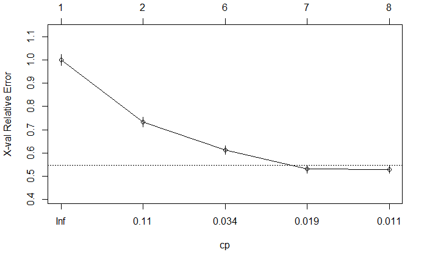

```r
plotcp(tree_model) # Gives a visual representation of the cross-validation results
```

```r
prune_tree <- prune(tree_model, cp = tree_model$cptable[which.min(tree_model$cptable[,"xerror"]), "CP"])
prune_tree
```

```
n= 51206

node), split, n, loss, yval, (yprob)
      * denotes terminal node

 1) root 51206 1733 Fully Paid (0.033843690 0.966156310)
   2) pymnt_plan=Apr-2017,Current,Fully Paid,In Grace Period,Jun-2017,Late (31-120 days),May-2017,Not Verified,Verified,y 506   22 Default (0.956521739 0.043478261) *
   3) pymnt_plan=n 50700 1249 Fully Paid (0.024635108 0.975364892)
     6) last_pymnt_d=Aug-2017,Jul-2017,Jun-2017 5773 1002 Fully Paid (0.173566603 0.826433397)
      12) out_prncp>=158.64 3970  980 Fully Paid (0.246851385 0.753148615)
        24) last_pymnt_d=Jul-2017,Jun-2017 227    0 Default (1.000000000 0.000000000) *
        25) last_pymnt_d=Aug-2017 3743  753 Fully Paid (0.201175528 0.798824472)
          50) issue_d=May-2017 547  233 Default (0.574040219 0.425959781) *
          51) issue_d=Apr-2017,Jun-2017 3196  439 Fully Paid (0.137359199 0.862640801) *
      13) out_prncp< 158.64 1803   22 Fully Paid (0.012201886 0.987798114)
        26) total_pymnt< 998.2177 22    0 Default (1.000000000 0.000000000) *
        27) total_pymnt>=998.2177 1781    0 Fully Paid (0.000000000 1.000000000) *
     7) last_pymnt_d=Apr-2017,May-2017,Sep-2017 44927  247 Fully Paid (0.005497808 0.994502192)
      14) total_rec_prncp< 19.765 47    0 Default (1.000000000 0.000000000) *
      15) total_rec_prncp>=19.765 44880  200 Fully Paid (0.004456328 0.995543672) *
```

## 3.5 Final Tree

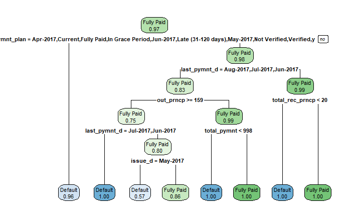

```r
library(rpart.plot)
# Plot the pruned tree with the probability of the fitted class
rpart.plot(prune_tree, extra = 8)
```

> The tree classifier choose the spilt variables: issue_d, last_pymnt_d, out_prncp, pymnt_plan, total_pymnt, total_rec_prncp.

It turns out that the most reasonable detection for a credit default is the variable `pymnt_plan` and the levels: Apr-2017, Current, Fully Paid, In Grace Period, Jun-2017, Late (31-120 days), May-2017, Not Verified, Verified, y. Whereas the level n leads to further considerations.

# 4. Validation

Use the test data set for predict the classes of the credit and evaluation the tree classifier. The Classifier estimate the probability for each observation of being either in class “Default” or “Fully Paid”. To decide the class, following decision boundary is applied: **P(Fully Paid) < 0.5 $\rightarrow$ class = Default**.

**Predict**

```r
# Predict the class
tmp <- cbind(df$test %>% select(l_state),
             predict(prune_tree, df$test %>% select(-l_state) ) ) %>%
  mutate(l_state_pred = ifelse(`Fully Paid` < 0.5, "Default", "Fully Paid"))
tmp %>% head()
```

|  | l_state | Default | Fully Paid | l_state_pred |
| --- | --- | --- | --- | --- |
| 1 | Fully Paid | 0.004456328 | 0.9955437 | Fully Paid |
| 2 | Fully Paid | 0.004456328 | 0.9955437 | Fully Paid |
| 3 | Fully Paid | 0.004456328 | 0.9955437 | Fully Paid |
| 4 | Fully Paid | 0.004456328 | 0.9955437 | Fully Paid |
| 5 | Fully Paid | 0.004456328 | 0.9955437 | Fully Paid |
| 6 | Fully Paid | 0.004456328 | 0.9955437 | Fully Paid |

```r
# Confusion matrix
table(tmp$l_state,tmp$l_state_pred, dnn = c("actual", "predict"))
```

```
            predict
actual       Default Fully Paid
  Default        550        363
  Fully Paid     112      24578
```

**Accurancy**

```r
# Accurancy tree model
print(paste0("Accuracy tree model: ", (tmp$l_state == tmp$l_state_pred) %>% mean(na.rm = TRUE)))
```

```
[1] "Accuracy tree model: 0.981447486622661"
```

```r
# Navive approach: classify all as Fully Paid
print(paste0("Accuracy trivial approach: ", (df$test$l_state == "Fully Paid") %>% mean))
```

```
[1] "Accuracy trivial approach: 0.96434011639261"
```

> The tree model classifier is slightly better (0.02) than the trivial approach with classify all credits as “Fully Paid”.

**Precicion**

```r
# CLass = Fully Paid
(tmp %>% filter(l_state == "Fully Paid" & l_state_pred == "Fully Paid") %>% nrow) /
  (tmp %>% filter(l_state == "Fully Paid" & l_state_pred == "Fully Paid") %>% nrow +
     tmp %>% filter(l_state == "Default" & l_state_pred == "Fully Paid") %>% nrow )
```

```
[1] 0.9854457
```

```r
# CLass = Default
(tmp %>% filter(l_state == "Default" & l_state_pred == "Default") %>% nrow) /
  (tmp %>% filter(l_state == "Fully Paid" & l_state_pred == "Default") %>% nrow +
     tmp %>% filter(l_state == "Default" & l_state_pred == "Default") %>% nrow )
```

```
[1] 0.8308157
```

**Recall/ hit rate**

```r
# CLass = Fully Paid
(tmp %>% filter(l_state == "Fully Paid" & l_state_pred == "Fully Paid") %>% nrow) /
  (tmp %>% filter(l_state == "Fully Paid" & l_state_pred == "Fully Paid") %>% nrow +
     tmp %>% filter(l_state == "Fully Paid" & l_state_pred == "Default") %>% nrow )
```

```
[1] 0.9954638
```

```r
# CLass = Default
(tmp %>% filter(l_state == "Default" & l_state_pred == "Default") %>% nrow) /
  (tmp %>% filter(l_state == "Default" & l_state_pred == "Default") %>% nrow +
     tmp %>% filter(l_state == "Default" & l_state_pred == "Fully Paid") %>% nrow )
```

```
[1] 0.6024096
```

**F - measure**
$$F = \frac{2 \times precision \times recall}{precission + recall}$$

```r
# Class = Fully Paid
2 * 0.9854457 * 0.9954638 / ( 0.9854457 + 0.9954638)
```

```
[1] 0.9904294
```

```r
# Class = Default
2 * 0.8308157 * 0.6024096/ ( 0.8308157 + 0.6024096)
```

```
[1] 0.6984127
```

> One can see that the model classify strongly in direction of the class “Fully Paid”. The overall performance in terms of precision and recall for the default class is with 70% appropriate. Considering merely the recall the predictive power of credit default, it is with 60%. This is low but still above 50% (which means better than a random guess).

# 5. Benchmark Classifier: single-hidden-layer neural network

As a benchmark approach a Neural Network with 1 hidden layer as a classifier is used with just numerical input variables. In order to guarantee the comparison of both model, the same split for test and training are used with a selection of all numerical variables.

## 5.1 Variable selection and Pre Processing

```r
# Select all numerical variables from the current traing data set
df$train_nn <-  df$train %>%
  select_(.dots = c(sapply(df$train ,class) %>%
                      data.frame() %>%
                      add_rownames() %>%
                      rename_("level" = ".") %>%
                      filter(level == "numeric") %>%
                      select(rowname) %>%
                      .$rowname,
                    "l_state"))
```

```
Deprecated, use tibble::rownames_to_column() instead.
```

```r
# Select all numerical variables from the current test data set
df$test_nn <-  df$test %>%
  select_(.dots = c(sapply(df$train ,class) %>%
                      data.frame() %>%
                      add_rownames() %>%
                      rename_("level" = ".") %>%
                      filter(level == "numeric") %>%
                      select(rowname) %>%
                      .$rowname,
                    "l_state"))
```

```
Deprecated, use tibble::rownames_to_column() instead.
```

**Normalize Data**

```r
# Train data
df$train_nn_norm <- lapply(df$train_nn %>%
                        select(-l_state, - na_rate),
                      FUN = function(x){normalize(x)}) %>%
  data.frame() %>%
  bind_cols(df$train_nn %>% select(l_state, na_rate))
# Test data
df$test_nn_norm <- lapply(df$test_nn %>%
                        select(-l_state, - na_rate),
                      FUN = function(x){normalize(x)}) %>%
  data.frame() %>%
  bind_cols(df$test_nn %>% select(l_state, na_rate))
```